# SSVEP reward - EEG results

Ivan Grahek & Antonio Schettino

2018-10-28

## About the code

Experiment: FSAReward (Ivan Grahek*, Antonio Schettino*, Gilles Pourtois, Ernst Koster, & Søren Andersen) (*: co-first authors) Code written by: Ivan Grahek & Antonio Schettino (2016-2018) Description: Code for the analysis of EEG data for Experiment 1 of the SSVEP - reward project.

## Topography & spectra

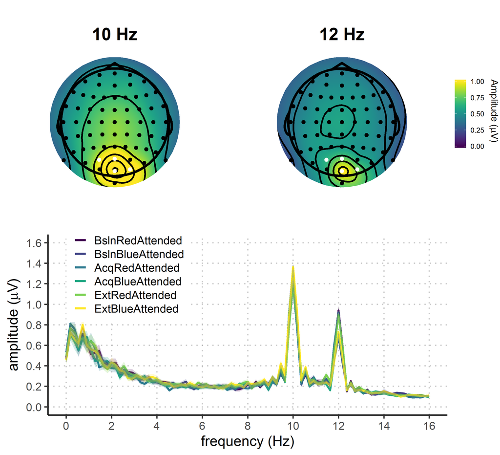

Topography and spectra

```r
# # Clear environemnt and import data------------------------------------------------------------------------------------------------------------------------------------------------------------------------------------------------------

# clear the environment
rm(list=ls())
# clear the console
cat("\014")
```

```r
#load packages and install them if they're not installed
if (!require("pacman")) install.packages("pacman")
pacman::p_load(reshape2,yarrr,BayesFactor,plyr,ez,schoRsch,brms,knitr,broom, brmstools, BEST)
# set seed
set.seed(42)
# Set working directory
setwd("C:/Users/igrahek/Documents/Studies/SSVEP Reward - Soren & Antonio/Experiment 1/SSVEP and reward/")
# import data
data.raw = read.csv2(file="./data/amplitudes_rewardBoth_wholeSample.csv",header=TRUE,na.strings="NaN") #only good behavior: amplitudes_rewardBoth.csv  # full sample: amplitudes_rewardBoth_wholeSample.csv POORPERF_amplitude_rewardBoth.csv

# Prepare the dataset------------------------------------------------------------------------------------------------------------------------------------------------------------------------------------------------------

# Reshape to long format
data = melt(data.raw,id.vars=c("Subject","Frequency"),
             measure.vars=c("BslnRedAttended","BslnBlueAttended","AcqRedAttended","AcqBlueAttended","ExtRedAttended","ExtBlueAttended"),
             variable.name="Condition",value.name="Amplitude")

# Sort the new dataframe by participant name
data = data[order(data$Subject),]

# Split the variable Condition based on capital letters
data$Condition = gsub("(?!^)(?=[[:upper:]])", " ", data$Condition, perl=T)

# Split the variable condition into multiple variables
Conditions = colsplit(data$Condition, pattern="\\s+",names = c('ExpPhase', 'ColorMoved',"attended","no","moved"))

# Add the variable defining which color is rewarded based on the participant number
data$RewardedColor = ifelse(data$Subject%%2==0,"Blue","Red") # if participant number is even, blue was rewarded

# Add the Conditions needed to the dataset
data$ExpPhase = Conditions[,1]
data$AttendedColor = Conditions[,2]

# Switch the Frequency to the color
data$RecordedFrequency = ifelse(data$Frequency==10,"Blue","Red") # if the recorded frequency is 10Hz assign Blue (color flickering at 10Hz), otherwise assign Red (color flickering at 12Hz)

# Make a new condition based on the attended color and the rewarded color
data$Condition = ifelse(data$AttendedColor==data$RewardedColor, "High_Rew","Low_Rew")

# Make a new condition based on the attended color and the recorded frequency
data$Attention = ifelse(data$AttendedColor==data$RecordedFrequency, "Att","NotAtt")

# Make a new condition based the Condition and the Attention
data$RecordingAndCondition = with(data, paste0(Condition,"_",Attention))

# Select variables which we want to keep
data = subset(data, select=c("Subject","RewardedColor","ExpPhase","AttendedColor","Condition","RecordedFrequency","Attention","RecordingAndCondition","Amplitude"))

# Sort the data
data = data[with(data, order(Subject)), ]

# Normalize the two frequencies
# Make a new variable with mean amplitude across all conditions for each participant and each frequency
data = ddply(data,.(Subject,RecordedFrequency),transform,
                    MeanAmplitude = mean(Amplitude,na.rm=TRUE),
                    SDAmplitude =   sd(Amplitude,na.rm=TRUE))

# Divide amplitudes in each Subject, Frequency, and Condition by the Mean Amplitude
data$Amplitude = data$Amplitude/data$MeanAmplitude

# Calculate the attention indexes - Selectivity (attended-unattended) & total enhancement (attended+unattended) (Andersen & Muller, 2010, PNAS)
data.diff = ddply(data, .(Subject,ExpPhase,Condition), transform, Selectivity = Amplitude[Attention=="Att"]-Amplitude[Attention=="NotAtt"],TotalEnhancement=Amplitude[Attention=="Att"]+Amplitude[Attention=="NotAtt"])
# Delete the Attention column and rows which are not necessary (indexes repeated twice)
data.diff = subset(data.diff,Attention=="Att") #keep only Att as it is equal to NotAtt
data.diff$Attention = NULL  #drop the Attention column

# Sort the data
data.diff$ExpPhase = factor(data.diff$ExpPhase, levels = c("Bsln","Acq","Ext"))
data.diff = data.diff[order(data.diff$Subject,data.diff$Condition,data.diff$ExpPhase),]

# Convert variables to be used in analyses into factors
data[c("Subject", "Condition","ExpPhase", "RewardedColor", "Attention", "RecordingAndCondition")] =
  lapply(data[c("Subject", "Condition","ExpPhase", "RewardedColor", "Attention", "RecordingAndCondition")], factor)

data.diff[c("Subject", "Condition","ExpPhase", "RecordingAndCondition")] =
  lapply(data.diff[c("Subject", "Condition","ExpPhase",  "RecordingAndCondition")], factor)
```

## Plots - raw data

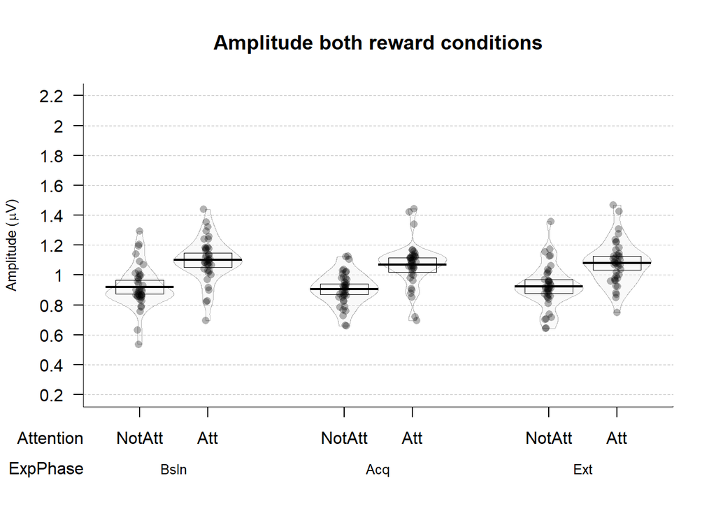

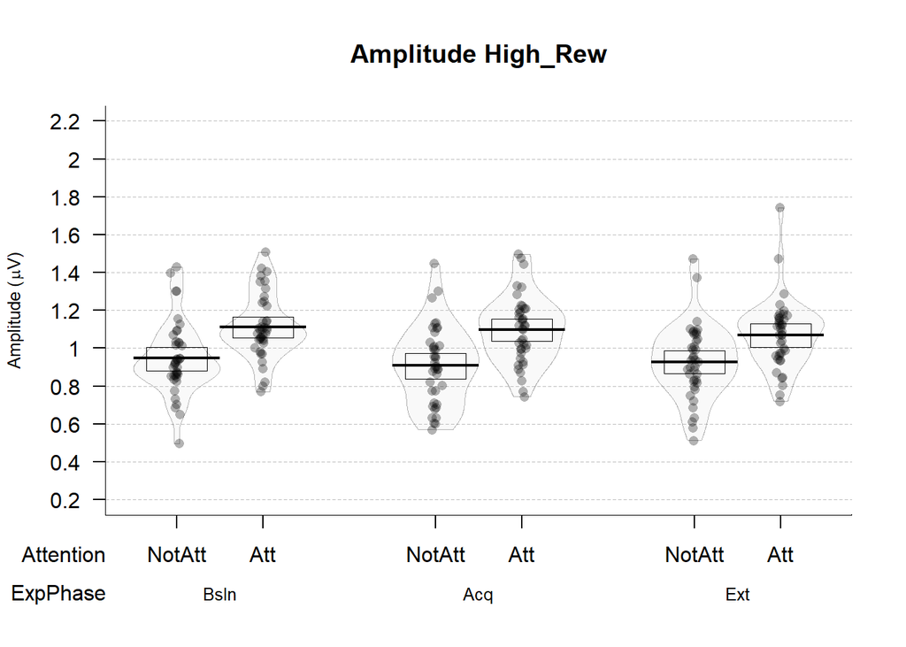

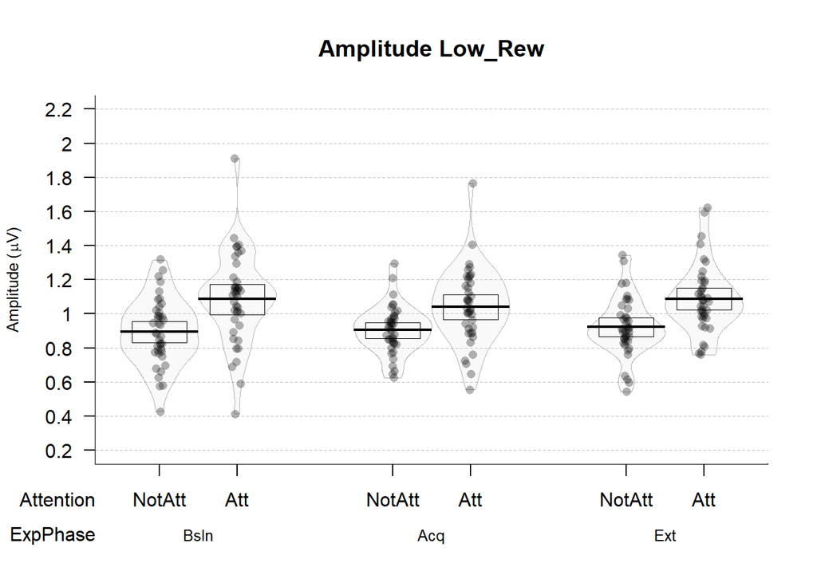

```r
# Plot amplitude across experiment phases------------------------------------------------------------------------------------------------------------------------------------------------------------------------------------------------------

plottingConditions = c("Amplitude both reward conditions","Amplitude High_Rew","Amplitude Low_Rew" )
for (i in 1:length(plottingConditions)){

  if(plottingConditions[i]=="Amplitude both reward conditions"){

    #Average over the reward condition and order data for plotting
    dataAmplitudePlot=ddply(data,.(Subject,Attention,ExpPhase),plyr::summarize,Amplitude=mean(Amplitude,na.rm=TRUE))

    #Order the data again in order to be able to plot Condition in the same order as in the other plots
    dataAmplitudePlot$Attention = factor(dataAmplitudePlot$Attention, levels = c("NotAtt","Att"))
    dataAmplitudePlot$ExpPhase = factor(dataAmplitudePlot$ExpPhase, levels = c("Bsln","Acq","Ext"))
    dataAmplitudePlot = dataAmplitudePlot[order(dataAmplitudePlot$Subject,dataAmplitudePlot$ExpPhase,dataAmplitudePlot$Attention),]}

  if(plottingConditions[i]=="Amplitude High_Rew"){dataAmplitudePlot=subset(data,Condition=="High_Rew")}

  if(plottingConditions[i]=="Amplitude Low_Rew"){

    #Order the data again in order to be able to plot Condition in the same order as in the other plots
    dataAmplitudePlot=subset(data,Condition=="Low_Rew")
    dataAmplitudePlot$Attention = factor(dataAmplitudePlot$Attention, levels = c("NotAtt","Att"))
    dataAmplitudePlot$ExpPhase = factor(dataAmplitudePlot$ExpPhase, levels = c("Bsln","Acq","Ext"))
    dataAmplitudePlot = dataAmplitudePlot[order(dataAmplitudePlot$Subject,dataAmplitudePlot$ExpPhase,dataAmplitudePlot$Attention),] #order the data again in order to be able to plot Condition in the same order as in the other plots
    }

# Pirate plot

  pirateplot(formula=Amplitude~Attention+ExpPhase, # dependent~independent variables
             data=dataAmplitudePlot, # data frame
             main=plottingConditions[i], # main title
             xlim=NULL, # x-axis: limits
             xlab="", # x-axis: label
             ylim=c(0.2,2.2), # y-axis: limits
             ylab=expression(paste("Amplitude (",mu,"V)")), # y-axis: label
             inf.method="hdi", # type of inference: 95% Bayesian Highest Density Intervals
             hdi.iter=5000, # number of iterations for estimation of HDI
             inf.within=Subject, # ID variable
             theme=0, # preset theme (0: use your own)
             # theme settings
             # pal="xman", # color palette [see piratepal(palette="all")]
             point.col="black", # points: color
             point.o=.3, # points: opacity (0-1)
             avg.line.col="black", # average line: color
             avg.line.lwd=2, # average line: line width
             avg.line.o=1, # average line: opacity (0-1)
             bar.b.col=NULL, # bars, border: color
             bar.lwd=0, # bars, border: line width
             bar.b.o=0, # bars, border: opacity (0-1)
             bar.f.col=NULL, # bars, filling: color
             bar.f.o=0, # bars, filling: opacity (0-1)
             inf.b.col="black", # inference band, border: color
             inf.lwd=0.1, # inference band, border: line width
             inf.b.o=1, # inference band, border: opacity (0-1)
             inf.f.col="black", # inference band, filling: color
             inf.f.o=0, # inference band, filling: opacity (0-1)
             bean.b.col="black", # bean border, color
             bean.lwd=0.6, # bean border, line width
             bean.lty=1, # bean border, line type (1: solid; 2:dashed; 3: dotted; ...)
             bean.b.o=0.3, # bean border, opacity (0-1)
             bean.f.col="gray", # bean filling, color
             bean.f.o=.1, # bean filling, opacity (0-1)
             cap.beans=TRUE, # max and min values of bean densities are capped at the limits found in the data
             # quant=c(.1,.9), # quantiles (e.g., 10th and 90th)
             # quant.col="black", # quantiles, line: color
             # quant.length=.7, # quantiles, horizontal line length
             # quant.lwd=2, # quantiles, line width
             sortx="sequential",
             gl.col="gray", # gridlines: color
             gl.lwd=c(.75,0), # gridlines: line width
             gl.lty=2, # gridlines: line type (1: solid; 2:dashed; 3: dotted; ...)
             cex.lab=0.8, # axis labels: size
             cex.axis=1, # axis numbers: size
             bty="l", # plot box type
             back.col="white") # background, color
}
```

## Statistics

```r
# Set the working directory in order to load the models
# Set working directory
setwd("C:/Users/igrahek/Documents/Studies/SSVEP Reward - Soren & Antonio/Experiment 1/SSVEP and reward/brms_models")

# # Set the intercept model
# data$ExpPhase=relevel(data$ExpPhase,ref="Bsln")
# data$Condition=relevel(data$Condition,ref="High_Rew")
# data$Attention=relevel(data$Attention,ref="Att")
#
#
# # Null model
# null = brm(Amplitude ~ 1 + (1|Subject),
#                               data=data,
#                               family=gaussian(),
#                               warmup = 2000,
#                               iter = 10000,
#                               save_all_pars = TRUE,
#                               control = list(adapt_delta = 0.99),
#                               cores = 4,
#                               sample_prior = TRUE)
# saveRDS(null,file="null.EEG.allsub.rds")
#
# # Exp phase model
# expphase = brm(Amplitude ~ ExpPhase + (ExpPhase|Subject),
#                                   data=data,
#                                   family=gaussian(),
#                                   warmup = 2000,
#                                   iter = 10000,
#                                   save_all_pars = TRUE,
#                                   control = list(adapt_delta = 0.99),
#                                   cores = 4,
#                                   sample_prior = TRUE)
# saveRDS(expphase,file="expphase.EEG.allsubs.rds")
#
# # Attention model
# attention = brm(Amplitude ~ Attention + (Attention|Subject),
#                                    data=data,
#                                    family=gaussian(),
#                                    warmup = 2000,
#                                    iter = 10000,
#                                    save_all_pars = TRUE,
#                                    control = list(adapt_delta = 0.99),
#                                    cores = 4,
#                                    sample_prior = TRUE)
# saveRDS(attention,file="attention.EEG.allsubs.rds")
#
# # Two main effects - phase and attention
# phaseANDattention = brm(Amplitude ~ ExpPhase + Attention + (ExpPhase + Attention|Subject),
#                                         data=data,
#                                         family=gaussian(),
#                                         warmup = 2000,
#                                         iter = 10000,
#                                         save_all_pars = TRUE,
#                                         control = list(adapt_delta = 0.99),
#                                         cores = 4,
#                                         sample_prior = TRUE)
# saveRDS(phaseANDattention,file="phaseANDattention.EEG.allsubs.rds")
#
# # Interaction between expphase and reward magnitude plus attention
# rewardTimesPhasePlusAtt = brm(Amplitude ~ Condition * ExpPhase + Attention + (Condition * ExpPhase + Attention|Subject),
#                          data=data,
#                          family=gaussian(),
#                          warmup = 2000,
#                          iter = 10000,
#                          save_all_pars = TRUE,
#                          control = list(adapt_delta = 0.99),
#                          cores = 4,
#                          sample_prior = TRUE)
# saveRDS(rewardTimesPhasePlusAtt,file="rewardTimesPhasePlusAtt.EEG.allsubs.rds")
#
# # Full model
# full = brm(Amplitude ~ Condition * ExpPhase * Attention + (Condition * ExpPhase * Attention|Subject),
#                               data=data,
#                               family=gaussian(),
#                               warmup = 2000,
#                               iter = 10000,
#                               save_all_pars = TRUE,
#                               control = list(adapt_delta = 0.99),
#                               cores = 4,
#                               sample_prior = TRUE)
# saveRDS(full,file="full.EEG.allsubs.rds")
#
# #Trial
# #full = brm(Amplitude ~ Condition * ExpPhase * Attention + (Condition * ExpPhase * Attention|Subject/Trial),
#
# # read in the models and comparisons
# null = readRDS("null.EEG.allsub.rds")
# attention = readRDS("attention.EEG.allsubs.rds")
# expphase = readRDS("expphase.EEG.allsubs.rds")
# phaseANDattention = readRDS("phaseANDattention.EEG.allsubs.rds")
# rewardTimesPhasePlusAtt = readRDS("rewardTimesPhasePlusAtt.EEG.allsubs.rds")
# full = readRDS("full.EEG.allsubs.rds")
# # waic = readRDS("compare.EEG.waic.allsubs.rds")
#
# # color_scheme_set("viridis")
# # pp_check(full, type = "stat_grouped", nsamples = 100, group = "ExpPhase")
#
# # WAIC
# compare.EEG.waic = WAIC(null, expphase, attention, phaseANDattention, rewardTimesPhasePlusAtt, full, compare = TRUE)
# saveRDS(compare.EEG.waic,file="compare.EEG.waic.allsubs.rds")
#
# # Weighted waic
# compare.EEG.waic.weights = model_weights(null, expphase, attention, phaseANDattention, rewardTimesPhasePlusAtt, full, weights = "waic")
# saveRDS(compare.EEG.waic.weights,file="compare.EEG.waic.weights")
#
# # Bayesian R2
# #Null
# bR2.null.EEG = bayes_R2(null)
# saveRDS(bR2.null.EEG,file="bR2.null.EEG")
# #ExpPhase
# bR2.expphase.EEG = bayes_R2(expphase)
# saveRDS(bR2.expphase.EEG,file="bR2.expphase.EEG")
# #Phase and attention
# bR2.phaseANDattention.EEG = bayes_R2(phaseANDattention)
# saveRDS(bR2.phaseANDattention.EEG,file="bR2.phaseANDattention.EEG")
# #Reward times phase plus attention
# bR2.rewardTimesPhasePlusAtt.EEG = bayes_R2(rewardTimesPhasePlusAtt)
# saveRDS(bR2.rewardTimesPhasePlusAtt.EEG,file="bR2.rewardTimesPhasePlusAtt.EEG")
# #Full
# bR2.full.EEG = bayes_R2(model.full.EEG)
# saveRDS(bR2.full.EEG,file="bR2.full.EEG")


# read in the models and comparisons
# null = readRDS("null.EEG.allsub.rds")
# attention = readRDS("attention.EEG.allsubs.rds")
# expphase = readRDS("expphase.EEG.allsubs.rds")
# phaseANDattention = readRDS("phaseANDattention.EEG.allsubs.rds")
# rewardTimesPhasePlusAtt = readRDS("rewardTimesPhasePlusAtt.EEG.allsubs.rds")
model.full.threefactors = readRDS("full.EEG.allsubs.attcc.rds")
compare.threefactors.EEG.waic = readRDS("compare.EEG.waic.allsubs.attcc.rds")
#compare.EEG.waic.weights = readRDS("compare.EEG.waic.weights.attcc")
bR2.null.EEG = readRDS("bR2.null.attcc.EEG")
bR2.expphase.EEG = readRDS("bR2.expphase.attcc.EEG")
bR2.attention.EEG = readRDS("bR2.attention.attcc.EEG")
bR2.phaseANDattention.EEG = readRDS("bR2.phaseANDattention.attcc.EEG")
bR2.phaseANDattention_interaction.EEG = readRDS("bR2.phaseANDattention_interaction.attcc.EEG")
bR2.rewardTimesPhasePlusAtt.EEG = readRDS("bR2.rewardTimesPhasePlusAtt.attcc.EEG")
bR2.full.EEG = readRDS("bR2.full.attcc.EEG")
```

### Model comparison with WAIC

```r
print(compare.threefactors.EEG.waic)
```

```
##                                                             WAIC    SE
## null                                                     -122.18 38.13
## expphase                                                 -115.28 38.04
## attention                                                -217.16 42.03
## phaseANDattention                                        -211.16 41.59
## phaseANDattention_interaction                            -208.51 40.85
## rewardTimesPhasePlusAtt                                  -295.65 42.90
## full                                                    -9345.56  4.83
## null - expphase                                            -6.90  2.90
## null - attention                                           94.98 19.12
## null - phaseANDattention                                   88.98 18.84
## null - phaseANDattention_interaction                       86.32 19.17
## null - rewardTimesPhasePlusAtt                            173.47 27.36
## null - full                                              9223.37 37.54
## expphase - attention                                      101.88 20.10
## expphase - phaseANDattention                               95.88 19.21
## expphase - phaseANDattention_interaction                   93.22 19.63
## expphase - rewardTimesPhasePlusAtt                        180.37 27.69
## expphase - full                                          9230.27 37.46
## attention - phaseANDattention                              -6.00  4.71
## attention - phaseANDattention_interaction                  -8.65  6.97
## attention - rewardTimesPhasePlusAtt                        78.49 21.94
## attention - full                                         9128.39 41.09
## phaseANDattention - phaseANDattention_interaction          -2.66  5.84
## phaseANDattention - rewardTimesPhasePlusAtt                84.49 21.74
## phaseANDattention - full                                 9134.39 40.63
## phaseANDattention_interaction - rewardTimesPhasePlusAtt    87.14 24.49
## phaseANDattention_interaction - full                     9137.05 39.95
## rewardTimesPhasePlusAtt - full                           9049.91 41.74
```

### Bayesian R squared

Null model

```r
print(bR2.null.EEG)
```

```
##       Estimate   Est.Error         Q2.5      Q97.5
## R2 0.002088328 0.002951665 2.055423e-06 0.01045571
```

Experiment phase

```r
print(bR2.expphase.EEG)
```

```
##      Estimate Est.Error        Q2.5      Q97.5
## R2 0.02530063 0.0156684 0.004092568 0.06388887
```

Attention model

```r
print(bR2.attention.EEG)
```

```
##     Estimate  Est.Error     Q2.5     Q97.5
## R2 0.2239253 0.03305686 0.158046 0.2872813
```

Phase and attention model

```r
print(bR2.phaseANDattention.EEG)
```

```
##     Estimate  Est.Error      Q2.5     Q97.5
## R2 0.2512095 0.03555356 0.1810649 0.3201975
```

Phase and attention interaction model

```r
print(bR2.phaseANDattention_interaction.EEG)
```

```
##     Estimate  Est.Error      Q2.5     Q97.5
## R2 0.2939299 0.03928555 0.2154312 0.3690463
```

Reward times phase plus attention model

```r
print(bR2.rewardTimesPhasePlusAtt.EEG)
```

```
##     Estimate  Est.Error      Q2.5     Q97.5
## R2 0.4633611 0.03634116 0.3888602 0.5316441
```

Full model

```r
print(bR2.full.EEG)
```

```
##    Estimate    Est.Error Q2.5 Q97.5
## R2        1 2.098032e-09    1     1
```

### Checking the best model

Plotting the chains

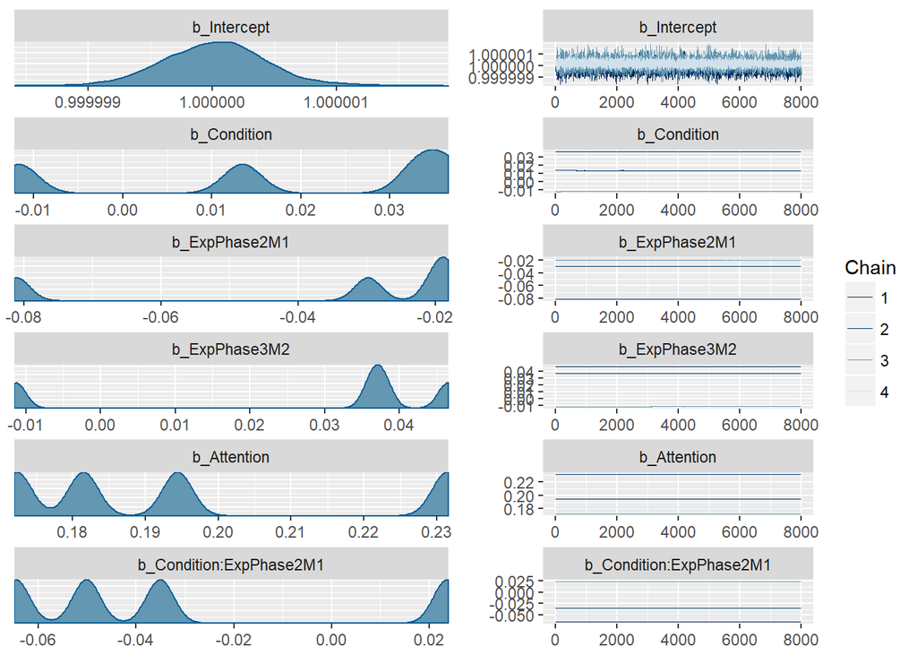

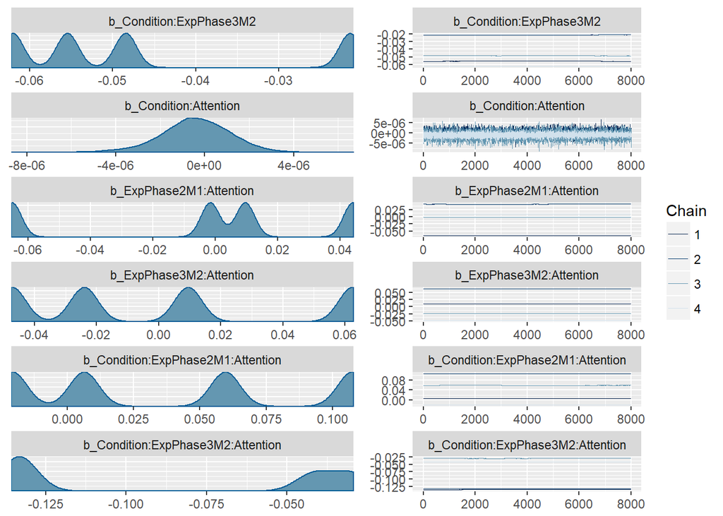

```r
# Plot chains
plot(model.full.threefactors, pars = "^b_", ask = FALSE, N=6)
```

Check model fit

```r
pp_check(model.full.threefactors)
```

```
## Using 10 posterior samples for ppc type 'dens_overlay' by default.
```

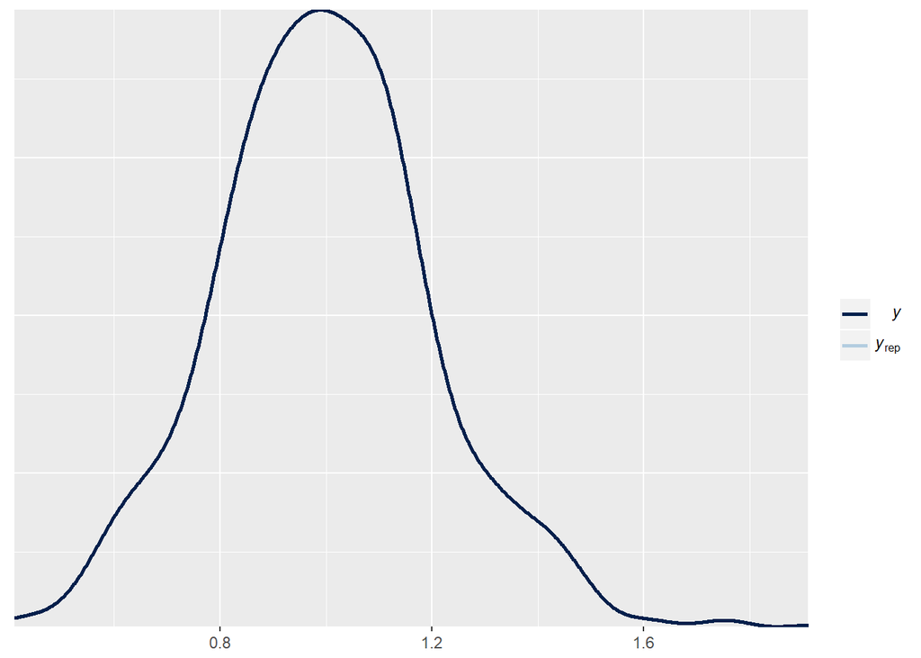

```r
pp_check(model.full.threefactors, "error_scatter_avg")
```

```
## Using all posterior samples for ppc type 'error_scatter_avg' by default.
```

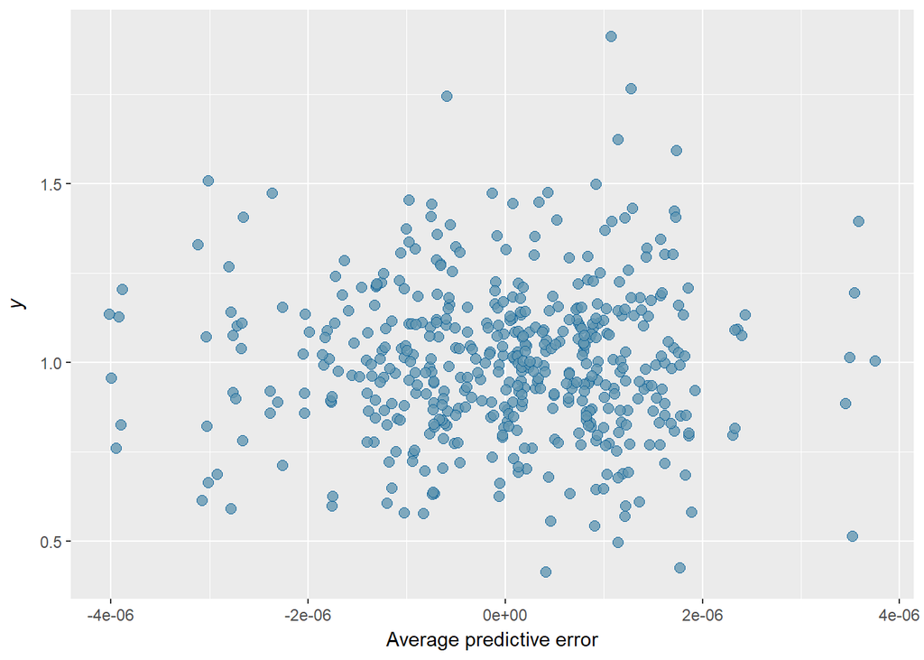

Summary of the best model

```r
# Summary of the best model
print(tidy(model.full.threefactors, par_type = "non-varying"), digits = 1)
```

```
##                               term estimate std.error  lower  upper
## 1                        Intercept    1e+00     4e-07  1e+00  1e+00
## 2                        Condition    2e-02     2e-02 -1e-02  4e-02
## 3                      ExpPhase2M1   -4e-02     3e-02 -8e-02 -2e-02
## 4                      ExpPhase3M2    3e-02     2e-02 -1e-02  5e-02
## 5                        Attention    2e-01     2e-02  2e-01  2e-01
## 6            Condition:ExpPhase2M1   -3e-02     3e-02 -6e-02  2e-02
## 7            Condition:ExpPhase3M2   -5e-02     2e-02 -6e-02 -2e-02
## 8              Condition:Attention   -4e-07     2e-06 -3e-06  2e-06
## 9            ExpPhase2M1:Attention   -3e-03     4e-02 -7e-02  4e-02
## 10           ExpPhase3M2:Attention    2e-04     4e-02 -5e-02  6e-02
## 11 Condition:ExpPhase2M1:Attention    4e-02     5e-02 -2e-02  1e-01
## 12 Condition:ExpPhase3M2:Attention   -8e-02     5e-02 -1e-01 -3e-02
```

### Plotting the best model

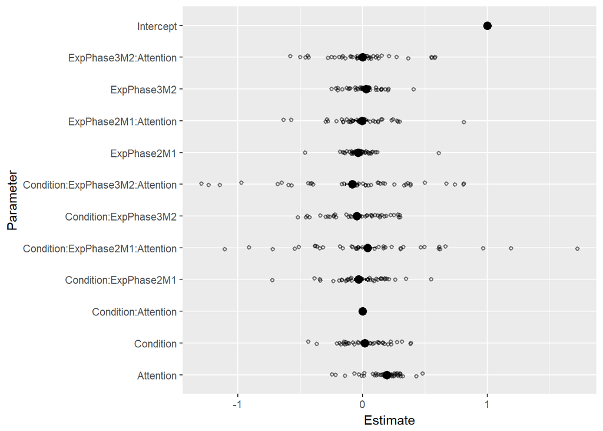

```r
# Plot the interaction between Phase and Attention in two conditions of reward probability
coefplot(model.full.threefactors)
```

```r
# conditions = data.frame(Attention = c(0.5, -0.5))
# plot(marginal_effects(model.full.threefactors, effects = "ExpPhase:Condition", conditions = conditions),ask=FALSE)
```

### Inference about the best model

```r
# post = posterior_samples(model.full.threefactors, "^b*")
#
# # Calculate posteriors for each condition
#
# ################################################ Baseline ####
#
# ##################### Attended
#
# ######### High reward
# Baseline_High_Attended = post[["b_Intercept"]] +
#   0.5 * post[["b_Attention"]]
# ######### Low reward
# Baseline_Low_Attended = post[["b_Intercept"]] +
#   0.5 * post[["b_Attention"]] +
#   post[["b_ConditionLow_Rew"]] +
#   post[["b_ConditionLow_Rew:Attention"]]
#
# ##################### Not Attended
#
# ######### High reward
# Baseline_High_NotAttended = post[["b_Intercept"]] +
#   (-0.5) * post[["b_Attention"]]
# ######### Low reward
# Baseline_Low_NotAttended = post[["b_Intercept"]] +
#   (-0.5) * post[["b_Attention"]] +
#   post[["b_ConditionLow_Rew"]] +
#   post[["b_ConditionLow_Rew:Attention"]]
#
# ################################################ Acquistion
#
# ##################### Attended
#
# ######### High reward
# Acquisition_High_Attended = post[["b_Intercept"]] +
#   0.5* post[["b_Attention"]] +
#   post[["b_ExpPhaseAcq"]] +
#   post[["b_ExpPhaseAcq:Attention"]]
# ######### Low reward
# Acquisition_Low_Attended = post[["b_Intercept"]] +
#   0.5* post[["b_Attention"]] +
#   post[["b_ConditionLow_Rew:Attention"]] +
#   post[["b_ExpPhaseAcq"]] +
#   post[["b_ExpPhaseAcq:Attention"]] +
#   post[["b_ConditionLow_Rew"]] +
#   post[["b_ConditionLow_Rew:ExpPhaseAcq"]] +
#   post[["b_ConditionLow_Rew:ExpPhaseAcq:Attention"]]
#
# ##################### Not Attended
#
# ######### High reward
# Acquisition_High_NotAttended = post[["b_Intercept"]] -
#   0.5* post[["b_Attention"]] +
#   post[["b_ExpPhaseAcq"]] +
#   post[["b_ExpPhaseAcq:Attention"]]
#
# ######### Low reward
# Acquisition_Low_NotAttended = post[["b_Intercept"]] -
#   0.5* post[["b_Attention"]] +
#   post[["b_ConditionLow_Rew:Attention"]] +
#   post[["b_ExpPhaseAcq"]] +
#   post[["b_ConditionLow_Rew"]] +
#   post[["b_ExpPhaseAcq:Attention"]] +
#   post[["b_ConditionLow_Rew:ExpPhaseAcq"]] +
#   post[["b_ConditionLow_Rew:ExpPhaseAcq:Attention"]]
#
# ################################################ Extinction
#
# ##################### Attended
#
# ######### High reward
# Extinction_High_Attended = post[["b_Intercept"]] +
#   0.5* post[["b_Attention"]] +
#   post[["b_ExpPhaseExt:Attention"]] +
#   post[["b_ExpPhaseExt"]]
# ######### Low reward
# Extinction_Low_Attended = post[["b_Intercept"]] +
#   0.5 * post[["b_Attention"]] +
#   post[["b_ExpPhaseExt:Attention"]] +
#   post[["b_ConditionLow_Rew:Attention"]] +
#   post[["b_ExpPhaseExt"]] +
#   post[["b_ConditionLow_Rew"]] +
#   post[["b_ConditionLow_Rew:ExpPhaseExt"]] +
#   post[["b_ConditionLow_Rew:ExpPhaseExt:Attention"]]
# ##################### Not Attended
#
# ######### High reward
# Extinction_High_NotAttended = post[["b_Intercept"]] +
#   (-0.5) * post[["b_Attention"]] +
#   post[["b_ExpPhaseExt"]] +
#   post[["b_Attention"]] +
#   post[["b_ExpPhaseExt:Attention"]]
# ######### Low reward
# Extinction_Low_NotAttended = post[["b_Intercept"]] +
#   (-0.5) * post[["b_Attention"]] +
#   post[["b_ConditionLow_Rew:Attention"]] +
#   post[["b_ExpPhaseExt"]] +
#   post[["b_ConditionLow_Rew"]] +
#   post[["b_ExpPhaseExt:Attention"]] +
#   post[["b_ConditionLow_Rew:ExpPhaseExt"]] +
#   post[["b_ConditionLow_Rew:ExpPhaseExt:Attention"]]
```

Check the difference between attended and not attended in baseline high rewarded

```r
# Diff_Att_NotAtt_Bsln_High = Baseline_High_Attended - Baseline_High_NotAttended
# plotPost(Diff_Att_NotAtt_Bsln_High, xlab = "", col = "#b3cde0", cex = 1, showCurve = FALSE, compVal = 0)
```

Check the difference between attended and not attended in baseline low rewarded

```r
# Diff_Att_NotAtt_Bsln_Low = Baseline_Low_Attended - Baseline_Low_NotAttended
# plotPost(Diff_Att_NotAtt_Bsln_Low, xlab = "", col = "#b3cde0", cex = 1, showCurve = FALSE, compVal = 0)
```

Check the difference between baseline and acquisition in high reward attended

```r
# Diff_Bsln_Acq_High_Att = Baseline_High_Attended - Acquisition_High_Attended
# plotPost(Diff_Bsln_Acq_High_Att, xlab = "", col = "#b3cde0", cex = 1, showCurve = FALSE, compVal = 0)
```

Check the difference between baseline and acquisition in low reward attended

```r
# Diff_Bsln_Acq_Low_Att = Baseline_Low_Attended - Acquisition_Low_Attended
# plotPost(Diff_Bsln_Acq_Low_Att, xlab = "", col = "#b3cde0", cex = 1, showCurve = FALSE, compVal = 0)
```

Check the difference between baseline and acquisition in high reward not attended

```r
# Diff_Bsln_Acq_High_NotAtt = Baseline_High_NotAttended - Acquisition_High_NotAttended
# plotPost(Diff_Bsln_Acq_High_NotAtt, xlab = "", col = "#b3cde0", cex = 1, showCurve = FALSE, compVal = 0)
```

Check the difference between baseline and acquisition in low reward not attended

```r
# Diff_Bsln_Acq_Low_NotAtt = Baseline_Low_NotAttended - Acquisition_Low_NotAttended
# plotPost(Diff_Bsln_Acq_Low_NotAtt, xlab = "", col = "#b3cde0", cex = 1, showCurve = FALSE, compVal = 0)
```

Check the difference between acquisition and extinction in high reward attended

```r
# Diff_Acq_Ext_High_Att = Acquisition_High_Attended - Extinction_High_Attended
# plotPost(Diff_Acq_Ext_High_Att, xlab = "", col = "#b3cde0", cex = 1, showCurve = FALSE, compVal = 0)
```

Check the difference between acquisition and extinction in low reward attended

```r
# Diff_Acq_Ext_Low_Att = Acquisition_Low_Attended - Extinction_Low_Attended
# plotPost(Diff_Acq_Ext_Low_Att, xlab = "", col = "#b3cde0", cex = 1, showCurve = FALSE, compVal = 0)
```

Check the difference between acquisition and extinction in high reward not attended

```r
# Diff_Acq_Ext_High_NotAtt = Acquisition_High_NotAttended - Extinction_High_NotAttended
# plotPost(Diff_Acq_Ext_High_NotAtt, xlab = "", col = "#b3cde0", cex = 1, showCurve = FALSE, compVal = 0)
```

Check the difference between acquisition and extinction in low reward not attended

```r
# Diff_Acq_Ext_Low_NotAtt = Acquisition_Low_NotAttended - Extinction_Low_NotAttended
# plotPost(Diff_Acq_Ext_Low_NotAtt, xlab = "", col = "#b3cde0", cex = 1, showCurve = FALSE, compVal = 0)
```